# Data IPM Jawa Barat

Indah Dzulkhariah

2025-09-04

# **Pemanggil Package**

```r
library(dplyr)
library(TTR)
library(forecast)
library(lmtest)
library(orcutt)
library(readxl)
library(HoRM)
```

# **Import Data**

Data yang digunakan adalah Indeks Pembangunan Manusia di Jawa Barat periode 2010-2024

```r
dtJABAR <- read_excel("C:/Users/USER/OneDrive/Documents/Semester 5/MPDW/Data IPM JABAR.xlsx")
dtJABAR
```

```
## # A tibble: 15 × 2
##    tahun   IPM
##    <dbl> <dbl>
##  1  2010  66.2
##  2  2011  66.7
##  3  2012  67.3
##  4  2013  68.2
##  5  2014  68.8
##  6  2015  69.5
##  7  2016  70.0
##  8  2017  70.7
##  9  2018  71.3
## 10  2019  72.0
## 11  2020  72.1
## 12  2021  72.4
## 13  2022  73.1
## 14  2023  73.7
## 15  2024  74.4
```

# **Eksplorasi Data**

```r
#Membentuk objek time series
data.ts<-ts(dtJABAR$IPM)
data.ts
```

```
## Time Series:
## Start = 1
## End = 15
## Frequency = 1
##  [1] 66.15 66.67 67.32 68.25 68.80 69.50 70.05 70.69 71.30 72.03 72.09 72.45
## [13] 73.12 73.74 74.43
```

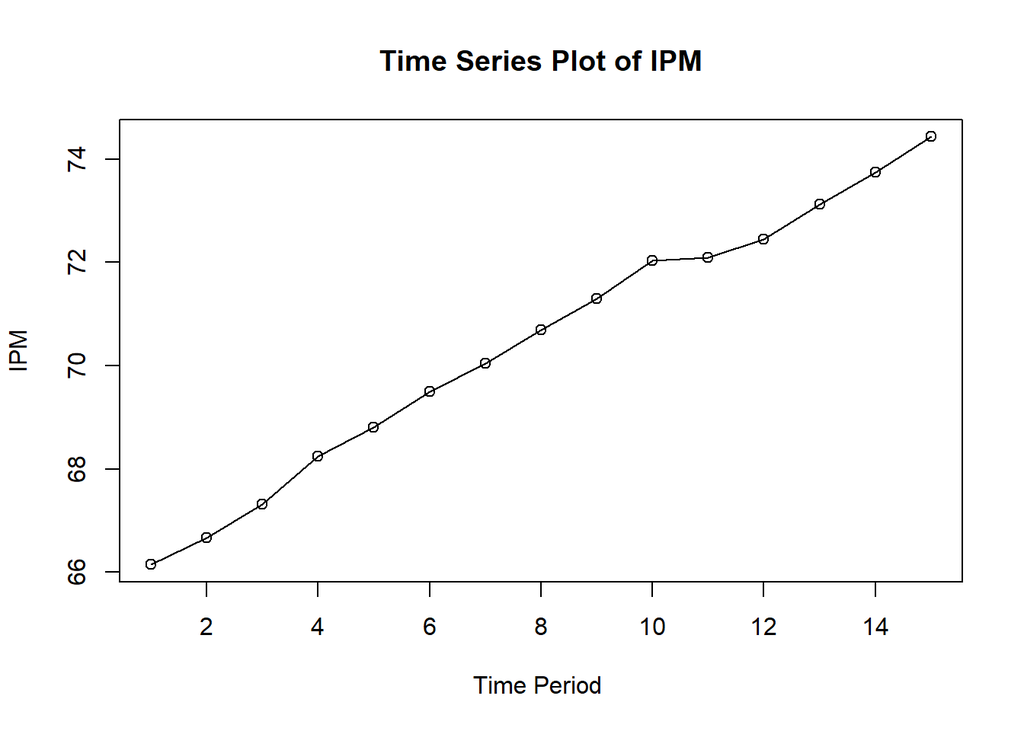

```r
#Membuat plot time series
ts.plot(data.ts, xlab="Time Period ", ylab="IPM", main= "Time Series Plot of IPM")
points(data.ts)
```

# **Regresi**

```r
#Pembuatan Model Regresi
#model regresi
model<- lm(IPM~tahun, data = dtJABAR)
summary(model)
```

```
##
## Call:
## lm(formula = IPM ~ tahun, data = dtJABAR)
##
## Residuals:
##      Min       1Q   Median       3Q      Max
## -0.30876 -0.21933 -0.06833  0.20545  0.43095
##
## Coefficients:
##               Estimate Std. Error t value Pr(>|t|)
## (Intercept) -1.099e+03  3.013e+01  -36.47 1.76e-14 ***
## tahun        5.799e-01  1.494e-02   38.81 7.91e-15 ***
## ---
## Signif. codes:  0 '***' 0.001 '**' 0.01 '*' 0.05 '.' 0.1 ' ' 1
##
## Residual standard error: 0.25 on 13 degrees of freedom
## Multiple R-squared:  0.9914, Adjusted R-squared:  0.9908
## F-statistic:  1506 on 1 and 13 DF,  p-value: 7.908e-15
```

Berdasarkan ringkasan model dapat diketahui bahwa hasil uji F memiliki p-value < α (5%). Artinya, minimal terdapat satu variabel yang berpengaruh nyata terhadap model. Hasil uji-t parsial kedua parameter regresi, yaitu intersep dan koefisien regresi juga menunjukkan hal yang sama, yaitu memiliki p-value < α (5%) sehingga nyata dalam taraf 5%. Selanjutnya dapat dilihat juga nilai $R^2 = 0.9914$ . Artinya, sebesar 99.14% keragaman nilai IPM dapat dijelaskan oleh peubah tahun. Hasil ini menunjukkan hasil yang bagus, seolah mendapatkan hasil terbaik. Namun, kita perlu melakukan uji terhadap sisaannya seperti berikut ini.

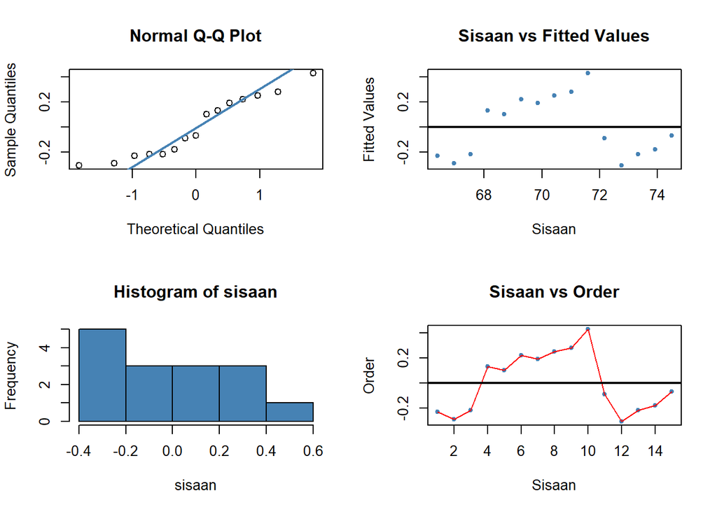

```r
#sisaan dan fitted value
sisaan<- residuals(model)
fitValue<- predict(model)

#Diagnostik dengan eksploratif
par(mfrow = c(2,2))
qqnorm(sisaan)
qqline(sisaan, col = "steelblue", lwd = 2)
plot(fitValue, sisaan, col = "steelblue", pch = 20, xlab = "Sisaan", ylab = "Fitted Values", main = "Sisaan vs Fitted Values")
abline(a = 0, b = 0, lwd = 2)
hist(sisaan, col = "steelblue")
plot(seq(1,15,1), sisaan, col = "steelblue", pch = 20, xlab = "Sisaan", ylab = "Order", main = "Sisaan vs Order")
lines(seq(1,15,1), sisaan, col = "red")
abline(a = 0, b = 0, lwd = 2)
```

Dua plot di samping kiri digunakan untuk melihat apakah sisaan menyebar normal. Normal Q-Q Plot di atas menunjukkan bahwa sisaan cenderung menyebar normal, tetapi histogram dari sisaan tidak menunjukkan demikian. Selanjutnya, dua plot di samping kanan digunakan untuk melihat autokorelasi. Plot Sisaan vs Fitted Value dan Plot Sisaan vs Order menunjukkan adanya pola pada sisaan. Untuk lebih lanjut akan digunakan uji formal melihat normalitas sisaan dan plot ACF dan PACF untuk melihat apakah ada autokorelasi atau tidak.

```r
#Melihat Sisaan Menyebar Normal/Tidak
#H0: sisaan mengikuti sebaran normal
#H1: sisaan tidak mengikuti sebaran normal
shapiro.test(sisaan)
```

```
##
##  Shapiro-Wilk normality test
##
## data:  sisaan
## W = 0.91718, p-value = 0.1744
```

```r
ks.test(sisaan, "pnorm", mean=mean(sisaan), sd=sd(sisaan))
```

```
##
##  Exact one-sample Kolmogorov-Smirnov test
##
## data:  sisaan
## D = 0.17061, p-value = 0.7139
## alternative hypothesis: two-sided
```

Berdasarkan uji formal Saphiro-Wilk dan Kolmogorov-Smirnov didapatkan nilai p-value > α (5%). Artinya, cukup bukti untuk menyatakan sisaan berdistribusi normal.

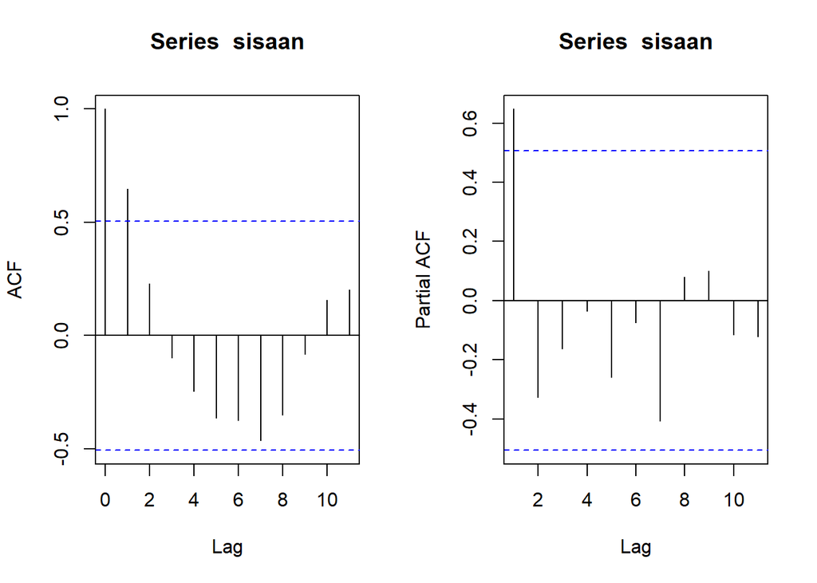

```r
#ACF dan PACF identifikasi autokorelasi
par(mfrow = c(1,2))
acf(sisaan)
pacf(sisaan)
```

```r
#Deteksi autokorelasi dengan uji-Durbin Watson
#H0: tidak ada autokorelasi
#H1: ada autokorelasi
dwtest(model)
```

```
##
##  Durbin-Watson test
##
## data:  model
## DW = 0.63367, p-value = 0.0001574
## alternative hypothesis: true autocorrelation is greater than 0
```

Berdasarkan hasil uji Durbin–Watson diperoleh nilai $DW = 0.63367$ dengan $p\text{-value} = 0.0001574$. Dari tabel Durbin–Watson pada taraf nyata 5% didapatkan $DL = 1.0770$ dan $DU = 1.3605$. Karena nilai $DW < d_L$, maka $H_0$ ditolak dan dapat disimpulkan bahwa terdapat **autokorelasi positif** pada residu model. Nilai $p\text{-value} < 0.05$ dapat disimpulkan bahwa tolak H0, cukup bukti mengatakan adanya autokorelasi. Oleh karena itu, diperlukan penangan autokorelasi. Penanganan yang akan digunakan menggunakan dua metode, yaitu Cochrane-Orcutt dan Hildret-Lu.

# **Penanganan Autokorelasi**

## **Metode Cochrane-Orcutt**

```r
#Penanganan Autokorelasi Cochrane-Orcutt
modelCO<-cochrane.orcutt(model)
modelCO
```

```
## Cochrane-orcutt estimation for first order autocorrelation
##
## Call:
## lm(formula = IPM ~ tahun, data = dtJABAR)
##
##  number of interaction: 13
##  rho 0.656022
##
## Durbin-Watson statistic
## (original):    0.63367 , p-value: 1.574e-04
## (transformed): 1.74572 , p-value: 2.041e-01
##
##  coefficients:
##  (Intercept)        tahun
## -1045.838904     0.553485
```

Hasil keluaran model setelah dilakukan penanganan adalah sebagai berikut.

$$y_i = -1045.838904 + 0.553485 x_t$$

## **Metode Hildreth-Lu**

Penanganan kedua adalah menggunakan metode Hildreth-Lu. Metode ini akan mencari nilai SSE terkecil dan dapat dicari secara manual maupun menggunakan packages.

```r
#Penanganan Autokorelasi Hildreth lu
# Hildreth-Lu
hildreth.lu.func<- function(r, model){
  x <- model.matrix(model)[,-1]
  y <- model.response(model.frame(model))
  n <- length(y)
  t <- 2:n
  y <- y[t]-r*y[t-1]
  x <- x[t]-r*x[t-1]

  return(lm(y~x))
}

#Pencariab rho yang meminimumkan SSE
r <- c(seq(0.1,0.9, by= 0.1))
tab <- data.frame("rho" = r, "SSE" = sapply(r, function(i){deviance(hildreth.lu.func(i, model))}))
round(tab, 4)
```

```
##   rho    SSE
## 1 0.1 0.6448
## 2 0.2 0.5632
## 3 0.3 0.4977
## 4 0.4 0.4484
## 5 0.5 0.4151
## 6 0.6 0.3980
## 7 0.7 0.3971
## 8 0.8 0.4122
## 9 0.9 0.4435
```

Pertama-tama akan dicari di mana kira-kira **ρ** yang menghasilkan SSE minimum. Pada hasil di atas terlihat **ρ** minimum ketika 0.7. Namun, hasil tersebut masih kurang teliti sehingga akan dicari kembali **ρ** yang lebih optimum dengan ketelitian yang lebih. Jika sebelumnya jarak antar **ρ** yang dicari adalah 0.1, kali ini jarak antar **ρ** adalah 0.001 dan dilakukan pada selang 0.6 sampai dengan 0.9.

```r
#Rho optimal di sekitar 0.4
rOpt <- seq(0.6,0.9, by= 0.001)
tabOpt <- data.frame("rho" = rOpt, "SSE" = sapply(rOpt, function(i){deviance(hildreth.lu.func(i, model))}))
head(tabOpt[order(tabOpt$SSE),])
```

```
##      rho       SSE
## 57 0.656 0.3955105
## 58 0.657 0.3955113
## 56 0.655 0.3955114
## 59 0.658 0.3955137
## 55 0.654 0.3955138
## 60 0.659 0.3955177
```

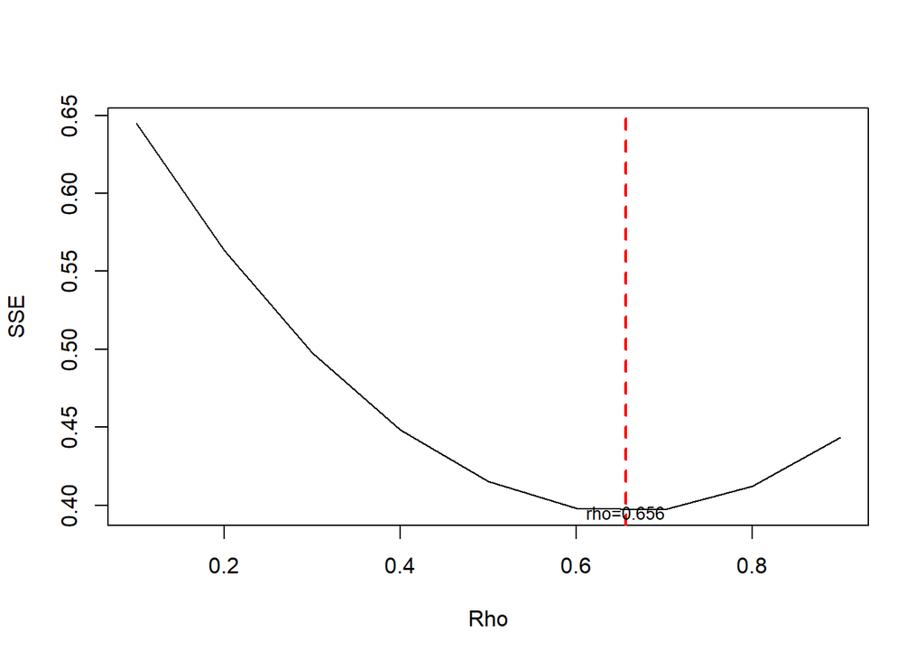

```r
#Grafik SSE optimum
par(mfrow = c(1,1))
plot(tab$SSE ~ tab$rho , type = "l", xlab = "Rho", ylab = "SSE")
abline(v = tabOpt[tabOpt$SSE==min(tabOpt$SSE),"rho"], lty = 2, col="red",lwd=2)
text(x=0.656, y=0.3955105   , labels = "rho=0.656", cex = 0.8)
```

Perhitungan yang dilakukan aplikasi R menunjukkan bahwa nilai **ρ** optimum, yaitu saat SSE terkecil terdapat pada nilai **ρ=0.656**. Hal tersebut juga ditunjukkan pada plot. Selanjutnya, model dapat didapatkan dengan mengevaluasi nilai **ρ** ke dalam fungsi hildreth.lu.func, serta dilanjutkan dengan pengujian autokorelasi dengan uji Durbin-Watson. Namun, setelah pengecekan tersebut tidak lupa koefisien regresi tersebut digunakan untuk transformasi balik. Persamaan hasil transformasi itulah yang menjadi persamaan sesungguhnya.****

```r
#Model terbaik
modelHL <- hildreth.lu.func(0.656, model)
summary(modelHL)
```

```
##
## Call:
## lm(formula = y ~ x)
##
## Residuals:
##      Min       1Q   Median       3Q      Max
## -0.36218 -0.07714  0.01530  0.10784  0.24710
##
## Coefficients:
##               Estimate Std. Error t value Pr(>|t|)
## (Intercept) -359.76988   24.30650  -14.80 4.53e-09 ***
## x              0.55349    0.03499   15.82 2.11e-09 ***
## ---
## Signif. codes:  0 '***' 0.001 '**' 0.01 '*' 0.05 '.' 0.1 ' ' 1
##
## Residual standard error: 0.1815 on 12 degrees of freedom
## Multiple R-squared:  0.9542, Adjusted R-squared:  0.9504
## F-statistic: 250.2 on 1 and 12 DF,  p-value: 2.114e-09
```

```r
#Transformasi Balik
cat("y = ", coef(modelHL)[1]/(1-0.656), "+", coef(modelHL)[2],"x", sep = "")
```

```
## y = -1045.843+0.5534873x
```

Setelah dilakukan tranformasi balik, didapatkan model dengan metode Hildreth-Lu sebagai berikut.

$$y_i = -1045.843 + 0.5534873 x_t$$

```r
#Deteksi autokorelasi
dwtest(modelHL)
```

```
##
##  Durbin-Watson test
##
## data:  modelHL
## DW = 1.7457, p-value = 0.2041
## alternative hypothesis: true autocorrelation is greater than 0
```

# **Perbandingan Model**

```r
sseModelawal <- sum(residuals(model)^2)
sseModelCO <- sum(residuals(modelCO)^2)
sseModelHL <- sum(residuals(modelHL)^2)


n <- length(dtJABAR$IPM)

mseModelawal <- sseModelawal / n
mseModelCO   <- sseModelCO   / n
mseModelHL   <- sseModelHL   / n
```

```r
akurasi <- matrix(c(sseModelawal, sseModelCO, sseModelHL,
                    mseModelawal, mseModelCO, mseModelHL),
                  nrow = 2, byrow = TRUE)

colnames(akurasi) <- c("Model Awal", "Model Cochrane-Orcutt", "Model Hildreth-Lu")
rownames(akurasi) <- c("SSE", "MSE")

akurasi
```

```
##     Model Awal Model Cochrane-Orcutt Model Hildreth-Lu
## SSE 0.81248762            1.16328343        0.39551055
## MSE 0.05416584            0.07755223        0.02636737
```